# Next Word Prediction Engine

## Word count analysis routine

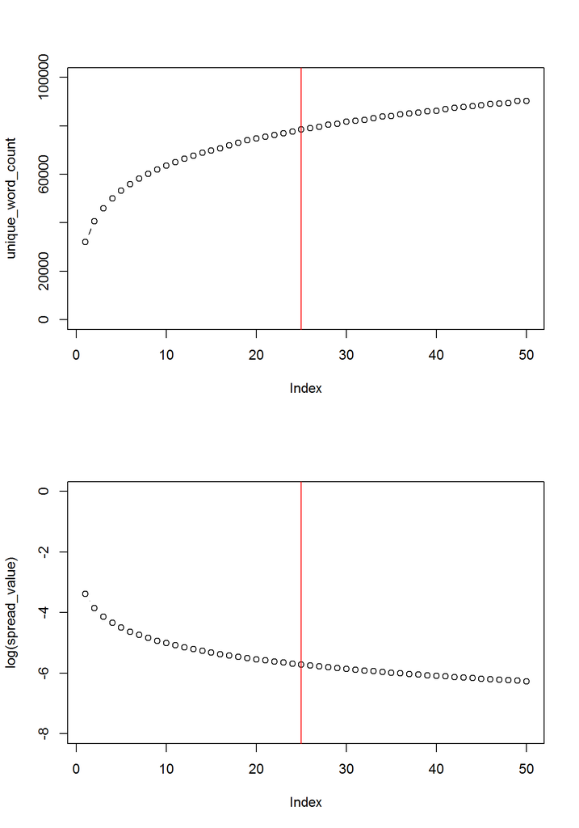

```r
if (file.exists("wordCountAnalysis.Rdata")) {
  #Look for locally saved analysis file and use it if found
  load(file = "wordCountAnalysis.Rdata")
} else {
  trials = 50
  unique_word_count = rep(NA, trials)
  spread_value = rep(NA, trials)

  for (i in 1:trials){
    print(paste("processing", i, '% of corpus'))
    corpus_percent = i/100 #Grab % of the documents at random
    sample_idx <- sample(corpus_size, corpus_percent*corpus_size)
    mydfm <- dfm(totalCorpus[sample_idx], ngrams=1, removePunct = TRUE,
                 removeTwitter = TRUE, removeURL = TRUE)
    token_counts <- topfeatures(mydfm, n=dim(mydfm)[2])
    token_counts <- token_counts[intersect(names(token_counts), my_dictionary$V1)]
    unique_word_count[i] = length(token_counts)
    spread_value[i] = length(token_counts)/sum(token_counts)
  }
  #Save the stats
  save(unique_word_count, spread_value, file="wordCountAnalysis.Rdata")
}
options(scipen=6)
par(mfrow = c(2,1))
plot(unique_word_count, type='b', ylim = c(0, 100000))
abline(v=25, col='red')
plot(log(spread_value), type='b', ylim = c(-8, -0))
abline(v=25, col='red')
```

Based on the above graph, it was decided that a quarter of the corpus would be processed for the remaining project. So one last look at word frequencies for 25% of the corpus, ignoring stop words for this visualization:

```r
corpus_percent = 25/100 #Grab % of the documents at random
sample_idx <- sample(corpus_size, corpus_percent*corpus_size)
mydfm <- dfm(totalCorpus[sample_idx], ngrams=1, removePunct = TRUE,
             removeTwitter = TRUE, removeURL = TRUE,
             ignoredFeatures = stopwords("english"))
#Top 100 words
token_counts <- topfeatures(mydfm, n=100)
```

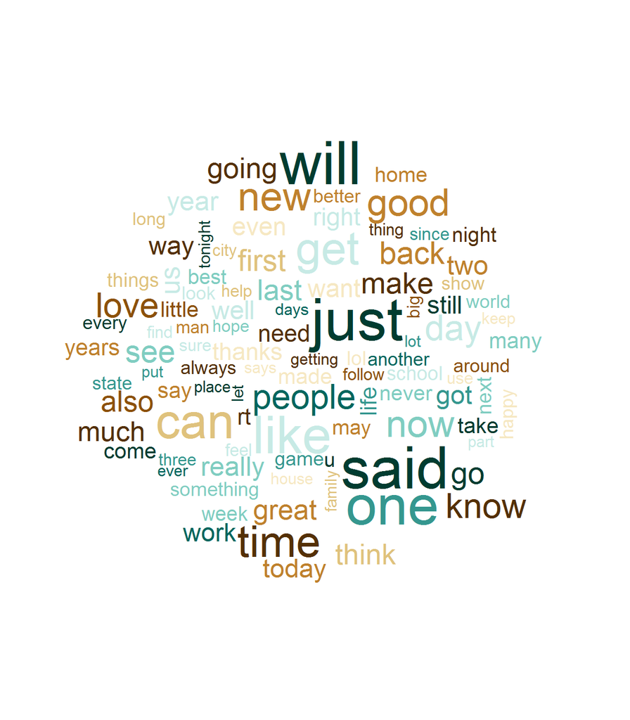

```r
wordcloud(names(token_counts), token_counts, random.color=TRUE, colors=brewer.pal(10, 'BrBG'))
```

The large majority of the top 100 words are monosyllabic

# The Corpus and n-grams

The primary purpose of this engine is to predict a word based or one or more previously entered words. To this end, the extraction of *n-grams* is required.

Some initial setup, including the selection of corpus indices and a dataframe to store some statistics of the n-gram processing.

```r
corpus_percent = 25/100 #Grab % of the documents at random
ptm <- proc.time()      #Capture starting time for performance analysis
set.seed(1)
sample_idx <- sample(corpus_size, corpus_percent*corpus_size)

#statistics to track
my_row_names <- c("corpus_percent", "sentences","ngrams_count","lookup_phrase_count","prediction_word_count","data_table_size_mb","file_size_mb","process_time_sec")
stats = data.frame(rep(0,length(my_row_names)), row.names = my_row_names)
names(stats) <- 'value'
stats['corpus_percent', 'value'] = corpus_percent * 100
```

`quanteda`’s `dfm()` allows for the specification of n-gram sizes when examining a corpus. It has built-in capabilities to remove punctuation, convert all text to lower-case and look for and remove patterns found in Twitter documents.

The first step, however, is to parse each document into its individual sentences so that n-grams are not constructs across sentences. For example, if a tweet had *“How are you? Windshield wipers have become expensive”* we would not want *“you windshield” to be captured as a viable n-gram.

```r
if (file.exists("sentences.Rdata")) {
  load(file = "sentences.Rdata")
} else {
  sentence_tokens <- toLower(tokenize(totalCorpus[sample_idx], what = "sentence", simplify = TRUE))
  save(sentence_tokens, file = "sentences.Rdata")
}
stats['sentences', 'value'] = length(sentence_tokens)
paste(formatC(length(sentence_tokens), format="d", big.mark=','), "sentences in the corpus portion")
```

```
## [1] "2,029,651 sentences in the corpus portion"
```

Once the sentences have been extracted, the corpus is processed 3 times: once for 2-grams, once for 3-grams and finally for 4-grams.

In each pass, the n-gram is separated into a *lookup phrase* and a *prediction word*. For example, the 4-gram *“weapons of mass destruction”* would be broken out into *“weapons of mass”* and *“destruction”*. Unique combinations of the lookup phrases, associated prediction words and their frequency counts were stored in a `data.table`. The results of each pass are saved to a data file.

```r
if (file.exists("ngrams.Rdata")) {
  load(file = "ngrams.Rdata")
  load(file = "ngrams_stats.Rdata")
} else {
  for (n_gram_size in 2:4){
    mydfm <- dfm(sentence_tokens, concatenator = " ", ngrams=n_gram_size, removePunct = TRUE, removeTwitter = TRUE, removeURL = TRUE)

    #Produce named list of n-gram counts with the names being the n-gram tokens
    token_counts <- topfeatures(mydfm, n=dim(mydfm)[2])
    stats['ngrams_count', 'value'] = stats['ngrams_count', 'value'] + length(token_counts)

    token_index <- 1:dim(mydfm)[2]
    #Grab the lookup phrases
    lookup <- unlist(strsplit(names(token_counts), split=" (?!.* )", perl=TRUE))[token_index * 2 - 1]
    #Grab the prediction words
    prediction <- unlist(strsplit(names(token_counts), split=" (?!.* )", perl=TRUE))[token_index * 2]

    #condense for uniqueness - purely for statistical reasons
    unique_lookup <- unique(lookup)
    unique_prediction <- unique(prediction)

    stats['lookup_phrase_count', 'value'] = stats['lookup_phrase_count', 'value'] + length(unique_lookup)
    stats['prediction_word_count', 'value'] = stats['prediction_word_count', 'value'] + length(unique_prediction)

    #Begin construction of file data table for this n-gram size
    ngram_counts <- as.vector(unname(token_counts))

    #Dynamically create variables dt2, dt3, dt4 to save the n-gram data
    dt <- data.table(lookup, prediction, ngram_counts)
    names(dt) <- c("lookup", "prediction", "count")
    setorder(dt, lookup, -count)
    setkey(dt, lookup)

    #Save n-gram data to its own variable name (dt1, dt2, etc)
    assign(paste("dt", n_gram_size, sep=""),dt)
  }
  #Continuing statistics gathering
  save(dt2, dt3, dt4, file='ngrams.Rdata')
  stats['data_table_size_mb', 'value'] = object.size(dt)/2^20
  stats['file_size_mb', 'value'] = file.size("ngrams.Rdata")/2^20
  stats['process_time_sec', 'value'] = (proc.time()-ptm)['elapsed']
  save(stats, file='ngrams_stats.Rdata')
}
stats$value <- formatC(stats$value, big.mark=',', digits=10, mode='integer')
stats
```

[output not shown]

With the n-gram data tables constructed, a lookup phrase can be used to quickly retrieve all of the prediction words and their frequencies within the corpus. For example:

```r
#Test lookup
print(dt2['it'][1:5])
```

```
##    lookup prediction count
## 1:     it        was 24153
## 2:     it         is 20300
## 3:     it         to  4948
## 4:     it      would  4751
## 5:     it       will  4444
```

```r
print(dt3['it goes'][1:5])
```

```
##     lookup prediction count
## 1: it goes         on    47
## 2: it goes         to    40
## 3: it goes       with    24
## 4: it goes       well    23
## 5: it goes       back    22
```

```r
print(dt4['it goes with'][1:5])
```

```
##          lookup prediction count
## 1: it goes with        the     5
## 2: it goes with        him     2
## 3: it goes with         me     2
## 4: it goes with      roast     2
## 5: it goes with    grilled     2
```

# Word Prediction Strategy

With the data table constructed, a predictive engine would be built next that would:

- take a submitted phrase and grab the last word, last two words and last three words (if the length of the phrase allows it)
- look up these predictive phrases in the `dt2`, `dt3` and `dt4` n-gram data tables.
- determine the relative frequencies of the resulting `prediction words’
- use *backoff* technique to compute the probabilities of the `predict` words using a weighted sum of the probabilities of the 3 n-gram sizes $P(w_{predict}|w_1 w_2 w_3) = \lambda{_1} P(w_{predict}|w_1) + \lambda_2 P(w_{predict}|w_2) + \lambda_3 P(w_{predict}|w_3)$ where $P(w_{predict}|w_1)$ is the probability of seeing $w_{predict}$ given the one-word *lookup* phrase $w_1$, $P(w_{predict}|w_2)$ is the probability of seeing $w_{predict}$ given the 2-word lookup phrase $w_2$, etc. The $\lambda$’s are weights to be determined.

# Next Steps

- Profanity filtering on the *predict* words (might as well leave them in on the *lookup* phrases, but I certainly wouldn’t want to offer up profanity as a suggestion)
- Reduce the size of the data tables to retain only the top five *predict* words for each *lookup* n-gram.
- Potentially reduce the number of *lookup* n-grams if more speed & efficiency is needed
- Develop the code to parse an input phrase and quickly return the top 5 words based on the above prediction strategy.
- Apply prediction engine to a test data set pulled from the corpus where a random 4 word phrase is pulled, the first 3 words used as a *lookup* and test whether the any of the 5 *predicted* words match the actual final word.